# MEDS5420 - Lecture 16 - de novo motif searches of ChIP data

March 24, 2025

# 1 Review of analysis pipeline

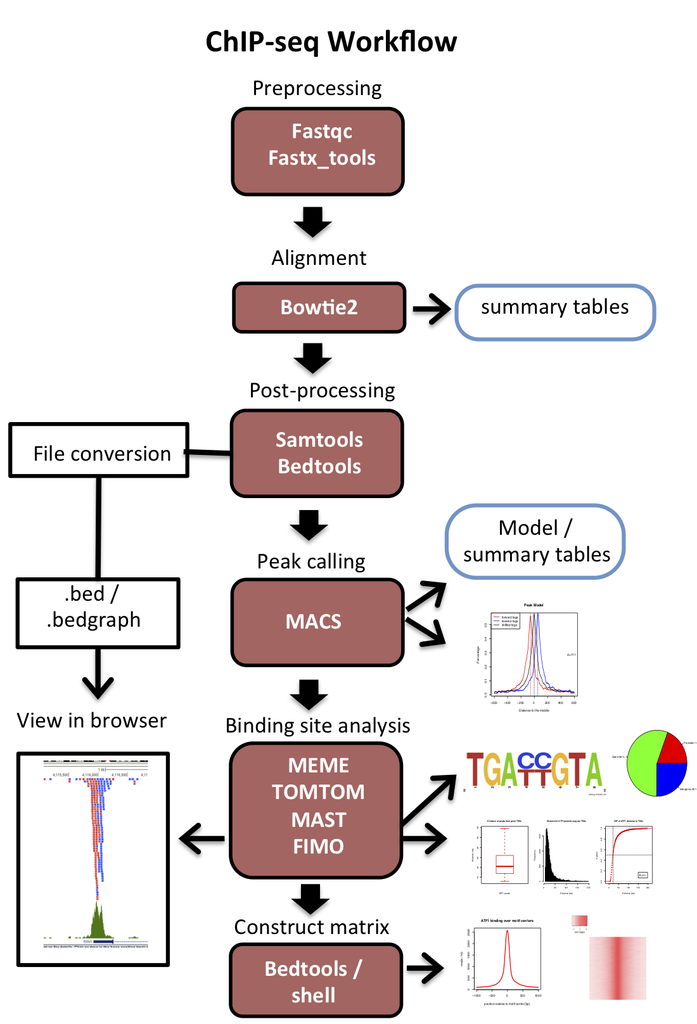

Figure 1: ChIP-seq analysis workflow

# 2 TODAY: de novo Motif searching with MEME

An important piece of information that can be gained from genomic binding data is the discovery of the underlying DNA motif that is bound by the transcription factor. There are many tools out there that will allow you to discover motifs. The **MEME** analysis suite is a popular and powerful set of tools that can allow you to perform several useful analyses on DNA sequences of interest, such as:

- Identify (de novo) enriched motifs with a set of sequences.
- Search for motifs of interest within a set of sequences.
- Scan large databases (genomes) for instances of specified motifs.
- Compare *de novo* motifs to databases of known motifs.

## 2.1 MEME: Multiple Em for Motif Elucidation

MEME Website: http://meme-suite.org/

Several steps must be performed prior to MEME analysis. Here is a summary list:

**1.** Create `bed` file with peak locations to analyze.  
- Short windows around summits.  
- Only most intense peaks needed.  
**2.** retrieve DNA sequences from regions to analyze  
**3.** Create a background base frequency model (part of the MEME suite)

MEME requires DNA sequences (in fasta format) of your regions of interest. Long sequences can decrease accuracy and take a long time to search through, so it is best to choose narrow regions. When finding motifs within ChIP-seq peaks we can **use our peak summits to center our analysis** since most TFs will be found in the immediate vicinity of their peak summits. We can use `bedtools slop` to create small windows around our summits:

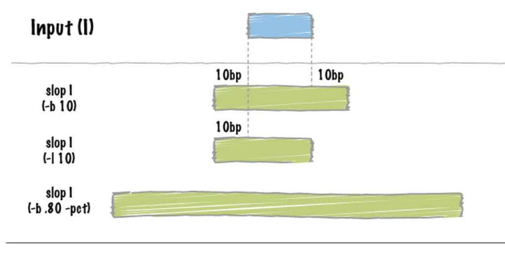

Figure 2: bedSlop

Let’s get 100bp window centered on peak summits (`/home/FCAM/meds5420/data/ATF1/ATF1_peaks/ATF1_summits.bed`) as follows (technically this is a 101 base window):

```bash
bedtools slop -i SUMMITS.BED -g <chrom_sizes> -b 50 > SUMMITS_100bp.bed
#-g is chromosome sizes file
#-b The number of basebairs to add to both sides
#-l The number of base pairs to subtract from the start coordinate
#-r The number of base pairs to add from the end coordinate
```

Another way to reduce time for running MEME and to increase accuracy is to run it on a subset of the most intense peaks. The peak intensity is in column 5 of the peak summits file. The summits .bed file can be sorted and parsed as follows:

```bash
sort -n -r -k5 SUMMITS_100bp.bed | head -200 > SUMMITS_100bp_top200.bed
# Performs numeric sort on column 5, reports it in
# reverse (-r) order (descending) and outputs the first 200 to output file.
```

Next, we can use `bedtools getfasta` to get the sequence within the desired intervals and return them in fasta format.

```bash
fastaFromBed -fi GENOME.fa -bed SUMMITS_100bp.bed -fo SUMMITS_100bp.fa
#-name: Will use the 'name' column from bed file to name sequence
#-fi: Input fasta sequences to retrieve interval sequences from
#-bed: Input bed file
#-fo: Output fasta file
```

Fasta formatted genome sequences and the genome sizes file for this class can be found at:

`/home/FCAM/meds5420/genomes/`  
If you get the error: `could not open index file /home/FCAM/meds5420/genomes/hg38.fa.fai for writing!`, then just copy the file to your directory and operate directly on the local file.

# 3 Loading `meme`

On Xanadu you should load meme version 5.4.1 every time. I worked with the HPC staff to ensure that `meme/5.4.1` can be run with the `-p` option, which allows for parallelization.

```bash
module load meme/5.4.1
```

## 3.1 Running `meme`

Now we can run MEME on the `.fasta` formatted sequences.

I recommend running the classic function for more sensitive and wider motifs, but it takes longer. I employ `-markov_order 3` in the command, which incorporates a background model on the fly using the file that specifies all k-mer frequencies up to the specified value. I typically just calculate it from the input file as opposed to random regions or the entire genome.

```bash
name=NAME_of EXPERIMENT
meme -oc ${name}.meme_output -objfun classic -evt 0.01 -searchsize 0 -minw 5 -maxw 18 -revcomp -dna -markov_order 3 -maxsize 100000000 SUMMITS_100bp.fa
```

There are a number of options to consider here:

- `-oc`: Folder to create where files will be written. Allows overwriting of previously made folders (use -o to disable this)
- `-dna`: Tell MEME to interpret symbols as nucleic acids (as opposed to amino acids)
- `-nmotifs`: number of motifs to search for
- `-evt`: stop searching for motifs when a motif cannot be found with a samller e-value (if `nmotifs` and `evt` are invoked, then `evt` will supercede the `nmotifs` option)
- `-minw`: minumum motif width in bases
- `-maxw`: maximum motif width in bases
- `-revcomp`: look for motif on both strands of DNA (do not assume strandedness)
- `-objfun`: `classic` is a sensitive algorithm to detect motifs, but it can be slow
- There are more options available. See manual or http://meme-suite.org/doc/meme.html?man_type=web.

The following files are placed in the designated output folder:

- `.xml` file of output (machine readable)
- `.txt` file of output (human readable)
- `.html` file of output browser viewable file of output
- `.eps` file of sequence logo for motif(s). Both forward and reverse complement

The output file contains:

- The found motifs
- A list of the sequences with the motifs with associated significance of the motifs
- A **P**osition **S**pecific **W**eight **M**atrix (PSWM) of the motif that can be used to generate the sequence logo as well as search for the motif in other sequences.

## 3.2 Finding occurences of motifs with MAST: Motif Alignment and Search Tool

Given a motif position weight matrix, one can search other for sequences for the occurance of that motif. For instance, finding a motif under a ChIP-seq peak with MEME does not mean that the motif is present at every binding site. We can use MAST to determine the number of sequences or found binding sites that have a specific motif.  
For usage go here: http://meme-suite.org/tools/mast  
Click on manual bar on left and view command line version for `MAST`.

The basic usage is simple:

```bash
mast MEME_output.txt SUMMITS_100bp.fa -oc mast_OUT_FOLDER
# The first file is the meme output with motifs that you want to search for
# The second file is the fasta formatted ChIP-seq regions we want to search for motifs within
# The third is the output folder as in MEME
```

The MAST output format is similar to `meme` and is placed in the designated output folder:

- `.xml` file of output (machine readable)
- `.txt` file of output (human readable)
- `.html` file of output browser viewable file of output

The output file contains the names of the sequences that have significant occurences of the motif.

Using the `-hit_list` option in mast creates a list of matches in a more easily processible format. However, this is sent to `stdout` and so must be redirected to a file.

```bash
#sending hits list to file by redirect
mast MEME_output.txt -hit_list SUMMITS_100bp.fa > mast_hits.txt
```

## 3.3 Scanning whole genomes for presence of motifs with FIMO: Find Individual Motif Occurrences

MAST is useful for determining if a sequence (or lists of them) have a specific motif. FIMO, is good for finding **ALL** significant occurrences of a motif within a sequence (i.e. a whole chromosome or genome).

You can then run FIMO to scan sequences for all occurrences of a motif. I usually set `--max-stored-scores` quite high and `--max-strand` provides the best match to identically overlapping sequences (only difference being the strand):

```bash
fimo --max-strand --max-stored-scores 10000000 --oc fimo_OUT_FOLDER MEME_output.txt hg38.fa
```

This is a basic run, but there are several options one can implement: http://meme-suite.org/doc/fimo.html?man_type=web

FIMO returns `.html`, `.gff3`, and `.tsv` (tab-separated values) files. I usually invoke the option `--text` and redirect (`>`) the `stdout` to a file name to create a text file output that contains a list of the motifs, their locations, and significance.

Here is a run that I recently:

```bash
fimo --max-strand --text --max-stored-scores 10000000 --oc fimo_atf1_out meme.txt hg38.fa > fimo_output.txt
```

After going through this workflow, there are a number of things one can do with these locations and bedtools.

- Determine the number of peaks with motifs - intersect peak file with `mast` output using `bedtools`.
- List of motifs not within peaks - intersect peak file with `fimo` output using `bedtools`, choose non-overlapping.

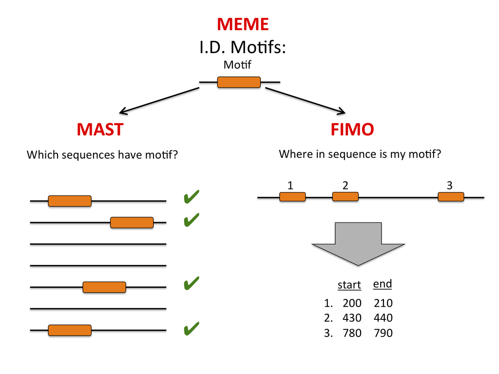

Figure 3: MAST vs FIMO

## 3.4 In class exercise:

# 4 Answers to In Class Exercise:

```bash
module load meme/5.4.1
module load bedtools

#Let's set a variable to the chromInfo file so we don't have to type it every time:
genome=/home/FCAM/meds5420/genomes/hg38.chrom.sizes
peaks=/home/FCAM/meds5420/data/ATF1/ATF1_peaks/ATF1_summits.bed

mkdir in_class_lec16
cd in_class_lec16

#starting from your own ATF1/peaks directory make a window around the summits
slopBed -i $peaks -g $genome -b 50 > ATF1_summit_101bp.bed
# get the top 200 peaks
sort -k5nr ATF1_summit_101bp.bed | head -n 200 > ATF1_summit_101bp_top200.bed

#you will have to cp the hg38.fa file because an intermediate file is made
cp /home/FCAM/meds5420/genomes/hg38.fa ./

fastaFromBed -fi hg38.fa -bed ATF1_summit_101bp_top200.bed -fo ATF1_summit_101bp_top200.fasta

meme ATF1_summit_101bp_top200.fasta -oc meme_ATF1 -nmotifs 2 -objfun classic -searchsize 0 -minw 5 -maxw 10 -revcomp -dna -markov_order 3 -maxsize 10000000

#Now we must get the fasta sequence for all peaks in order to use MAST on them
fastaFromBed -fi hg38.fa -bed ATF1_summit_101bp.bed -fo ATF1_summit_101bp.fasta

# Now run MAST on them to ID peaks with the MEME motifs.
# Check the manual for the options.

mast -hit_list meme_ATF1/meme.txt ATF1_summit_101bp.fasta > mast_ATF1_hits.txt

# To then run FIMO we should create a background file,

# Using our chromosome, which you can get from UCSC, or use hg38.fa
wget https://hgdownload.soe.ucsc.edu/goldenPath/hg38/bigZips/hg38.chromFa.tar.gz
tar -xzf hg38.chromFa.tar.gz
cp /home/FCAM/meds5420/genomes/chroms/chr17.fa ./
# recall I put them here /home/FCAM/meds5420/genomes/chroms

fasta-get-markov -m 3 chr17.fa > chr17_bkgrnd.txt

#Next run FIMO with the background file, MEME output and your chr.fasta to search
fimo --text --max-strand --max-stored-scores 10000000 --bgfile chr17_bkgrnd.txt ./meme_ATF1/meme.txt chr17.fa > fimo_ATF1_chr17.txt

#Convert FIMO output to bed

awk '{OFS="\t";} NR>1 {print $3, $4, $5, $7, $8, $6}' fimo_ATF1_chr17.txt > fimo_ATF1_chr17.bed

#Intersect FIMO output with peaks
intersectBed -wo -a fimo_ATF1_chr17.bed -b ATF1_summit_101bp.bed -g $genome > ATF1_chr17_motifs_in_peaks.txt

# to get all the fimo output files, note the tsv files is nearly identical to the txt file above
fimo --max-strand --max-stored-scores 10000000 -oc fimo_ATF1 --bgfile chr17_bkgrnd.txt ./meme_ATF1/meme.txt chr17.fa

# run meme with bfile on random intervals
randomBed -n 1000 -l 101 -g $genome > hg38_random_intervals.bed

fastaFromBed -fi hg38.fa -bed hg38_random_intervals.bed -fo hg38_random_intervals.fasta

fasta-get-markov -m 3 hg38_random_intervals.fasta > hg38_random_intervals_markov.txt

meme ATF1_summit_101bp_top200.fasta -oc meme_ATF1_bfile -nmotifs 2 -objfun classic -evt 0.01 -searchsize 0 -minw 5 -maxw 10 -revcomp -dna -bfile hg38_random_intervals_markov.txt -maxsize 10000000


Reporting:

#How many peaks are there on chr17?
grep -w chr17 ATF1_summit_101bp.bed > ATF1_chr17_peaks.bed
wc -l ATF1_chr17_peaks.bed

#What is the number of peaks (summit -/+ 50bp) on your chromosome with MAST called motifs:

grep "chr17:" mast_ATF1_hits.txt | cut -f1 -d " " | sort | uniq | wc -l

#how many FIMO motifs on chr17:
cat fimo_ATF1/fimo.tsv | grep "#" -v | grep "motif_id" -v | wc -l

#how many FIMO motifs in peaks?
wc -l ATF1_chr17_motifs_in_peaks.txt

#How many unique peaks in FIMO overlap?
cat ATF1_chr17_motifs_in_peaks.txt | cut -f 10 | sort | uniq | wc -l

# MAST and FIMO call motif instances a bit differently
```